# Prediction of Volume: LOO

Adam Festa

5/27/2018

## 0.1 Script objective

- Predict volume of all 57 families with a LOO

## 0.2 Load data

```r
# Load counts
load("/mnt/mnt/media/disk6/ARF/RNASEQ/counts/86kSalmon/Step3_LMM_animal.RData")
head(rownames(asreml.counts))
```

```
## [1] "ped(animal_id, var = T)_GR011"  "ped(animal_id, var = T)_N05052"
## [3] "ped(animal_id, var = T)_N07002" "ped(animal_id, var = T)_N07022"
## [5] "ped(animal_id, var = T)_N07029" "ped(animal_id, var = T)_N07051"
```

```r
asreml.counts <- asreml.counts[-c(1:94),]
head(rownames(asreml.counts))
```

```
## [1] "ped(animal_id, var = T)_1030" "ped(animal_id, var = T)_1028"
## [3] "ped(animal_id, var = T)_1087" "ped(animal_id, var = T)_1013"
## [5] "ped(animal_id, var = T)_1012" "ped(animal_id, var = T)_1061"
```

```r
# Load phenos
load("/mnt/mnt/media/disk6/ARF/RNASEQ/Breeding-Value-Prediction/disk6directory/resources/expt.dat.720.RData")
# Change factor to character and subset 3 columns
expt.dat.720$fam_id <- as.character(expt.dat.720$fam_id)
select.columns <- c("fam_id","animal_id","Volume","Volume Accuracy","Height","index_seq","batch")

# Remove missing phenotypes and subset for phenos which have counts
fam.phenos <- unique(expt.dat.720[-which(is.na(expt.dat.720$Volume) == T),select.columns])

# Edit rownames of asreml.counts
 sub.names <- gsub(pattern = "animal_id, var = T)_",replacement = "",x = rownames(asreml.counts))
 sub.names <- gsub("ped\\(", "", sub.names)

# Subset each count data to contain only rows which have phenos
select.rows <- which(sub.names %in% as.character(fam.phenos$animal_id))

asreml.counts <- asreml.counts[select.rows,]

select.rows <- which(as.character(fam.phenos$animal_id) %in% sub.names)
fam.phenos <- fam.phenos[select.rows,]
```

```r
final.r.names <- gsub(pattern = "animal_id, var = T)_",replacement = "",x = rownames(asreml.counts))
final.r.names <- gsub("ped\\(", "", final.r.names)
head(as.character(fam.phenos$animal_id))
```

```
## [1] "1030" "1061" "1082" "1065" "1008" "1043"
```

```r
head(final.r.names)
```

```
## [1] "1030" "1061" "1082" "1065" "1008" "1043"
```

```r
rownames(asreml.counts) <- paste0(final.r.names,".",fam.phenos$index_seq)
rownames(fam.phenos) <- paste0(fam.phenos$animal_id,".",fam.phenos$index_seq)
```

## 0.3 Generate family-level info

- Create family level phenotypes

```r
# First subset the unique fam, volume, batch combo to see what fams are in both batches
pheno.57 <- unique(fam.phenos[,c("fam_id","Volume","batch")])

# Identify which families were grown in both batches
crossover.fams <- names(which(table(pheno.57$fam_id) ==2))
crossover.fams
```

```
## [1] "N07056"  "N08001"  "N08103"  "N101027" "N111095"
```

```r
# Now get the unique list of family phenos
pheno.57 <- unique(fam.phenos[,c("fam_id","Volume","Volume Accuracy")])
```

- Create family mean counts

```r
fam.asreml.counts <- matrix(,nrow = 57,ncol=ncol(asreml.counts))
all.fams <- unique(as.character(fam.phenos$fam_id))
for(each.fam in 1:57){
 merge.bio.reps <-  which(fam.phenos$fam_id %in% all.fams[each.fam])
 if(length(merge.bio.reps) == 1){ fam.asreml.counts[each.fam,] <- asreml.counts[merge.bio.reps,]} else {
   fam.asreml.counts[each.fam,] <- apply(asreml.counts[merge.bio.reps,],2,mean)}
}
rownames(fam.asreml.counts) <- all.fams

rownames(pheno.57) <- pheno.57$fam_id
```

## 0.4 Predictions

- Establish the training and testing

### 0.4.1 Omic Kriging

```r
suppressPackageStartupMessages(library(OmicKriging))
suppressPackageStartupMessages(library(Metrics))
```

#### 0.4.1.1 All transcripts: BIO Reps

- Bio-reps: NO SCALING

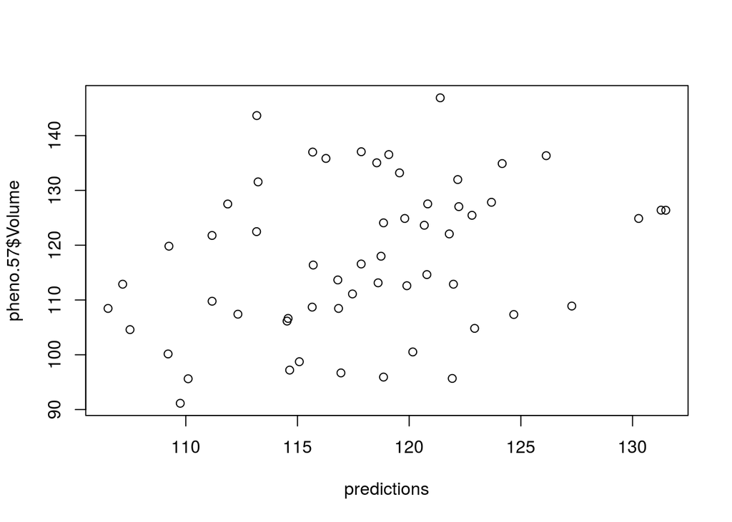

```r
cor.mat <- cor(t(scale(log2(asreml.counts + 1),center=F,scale = F)))
rownames(cor.mat) <- 1:190; colnames(cor.mat) <- 1:190
rownames(fam.phenos) <- 1:190

u.fams <- pheno.57$fam_id

predictions <- unlist(sapply(1:57,function(each.fam){
  TEST.rows <- which(fam.phenos$fam_id %in% u.fams[each.fam])
  TRAIN.rows <- c(1:190)[-TEST.rows]
  mean(okriging(idtest = TEST.rows,idtrain = TRAIN.rows,corlist = list(cor.mat),H2vec = c(.99),pheno = fam.phenos,phenoname = "Volume")[,2])
}))

plot(predictions,pheno.57$Volume)
```

```r
cor(predictions,pheno.57$Volume)
```

```
## [1] 0.3172757
```

- Bio-reps: SCALED, NO CENTERING

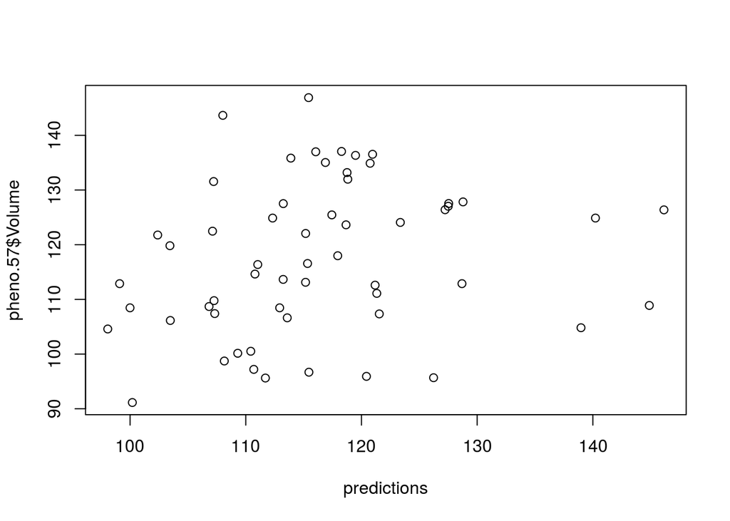

```r
cor.mat <- cor(t(scale(log2(asreml.counts + 1),center=F,scale = T)))
rownames(cor.mat) <- 1:190; colnames(cor.mat) <- 1:190
rownames(fam.phenos) <- 1:190

u.fams <- pheno.57$fam_id

predictions <- unlist(sapply(1:57,function(each.fam){
  TEST.rows <- which(fam.phenos$fam_id %in% u.fams[each.fam])
  TRAIN.rows <- c(1:190)[-TEST.rows]
  mean(okriging(idtest = TEST.rows,idtrain = TRAIN.rows,corlist = list(cor.mat),H2vec = c(.99),pheno = fam.phenos,phenoname = "Volume")[,2])
}))

plot(predictions,pheno.57$Volume)
```

```r
cor(predictions,pheno.57$Volume)
```

```
## [1] 0.2029611
```

- Bio-reps: SCALED & CENTERED

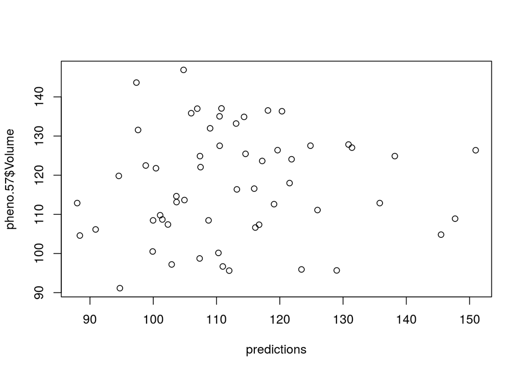

```r
cor.mat <- cor(t(scale(log2(asreml.counts + 1),center=T,scale = T)))
rownames(cor.mat) <- 1:190; colnames(cor.mat) <- 1:190
rownames(fam.phenos) <- 1:190
u.fams <- pheno.57$fam_id

predictions <- unlist(sapply(1:57,function(each.fam){
  TEST.rows <- which(fam.phenos$fam_id %in% u.fams[each.fam])
  TRAIN.rows <- c(1:190)[-TEST.rows]
  mean(okriging(idtest = TEST.rows,idtrain = TRAIN.rows,corlist = list(cor.mat),H2vec = c(.99),pheno = fam.phenos,phenoname = "Volume")[,2])
}))

plot(predictions,pheno.57$Volume)
```

```r
cor(predictions,pheno.57$Volume)
```

```
## [1] 0.06368849
```

*** The BEST result from Bio replicates is using log2 with NO SCALING/CENTERING

#### 0.4.1.2 All transcripts: FAMILY-level

- Fam reps: NO SCALING/CENTERING

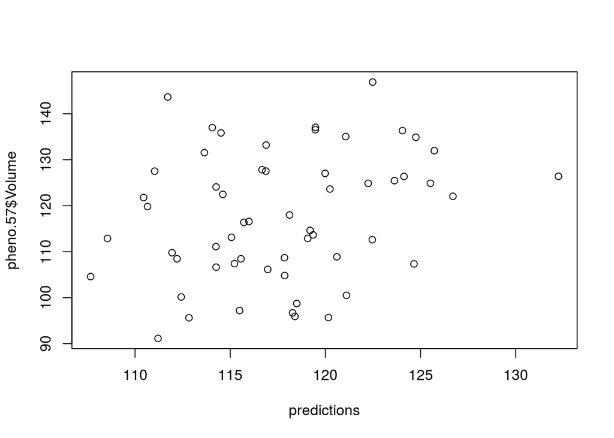

```r
cor.mat <- cor(t(scale(log2(fam.asreml.counts + 1),center=F,scale = F)))
u.fams <- colnames(cor.mat)
predictions <- unlist(sapply(1:57,function(each.fam){
  TEST.rows <- u.fams[each.fam]
  TRAIN.rows <- u.fams[-each.fam]
  okriging(idtest = TEST.rows,idtrain = TRAIN.rows,corlist = list(cor.mat),H2vec = c(.99),pheno = pheno.57,phenoname = "Volume")[,2]
}))

plot(predictions,pheno.57$Volume)
```

```r
cor(predictions,pheno.57$Volume)
```

```
## [1] 0.2624265
```

- Fam reps: SCALED, NO CENTERING

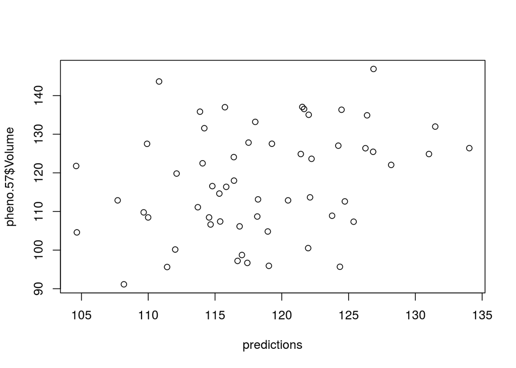

```r
cor.mat <- cor(t(scale(log2(fam.asreml.counts + 1),center=F,scale = T)))
u.fams <- colnames(cor.mat)
predictions <- unlist(sapply(1:57,function(each.fam){
  TEST.rows <- u.fams[each.fam]
  TRAIN.rows <- u.fams[-each.fam]
  okriging(idtest = TEST.rows,idtrain = TRAIN.rows,corlist = list(cor.mat),H2vec = c(.99),pheno = pheno.57,phenoname = "Volume")[,2]
}))

plot(predictions,pheno.57$Volume)
```

```r
cor(predictions,pheno.57$Volume)
```

```
## [1] 0.3087382
```

- Fam reps: SCALED & CENTERED

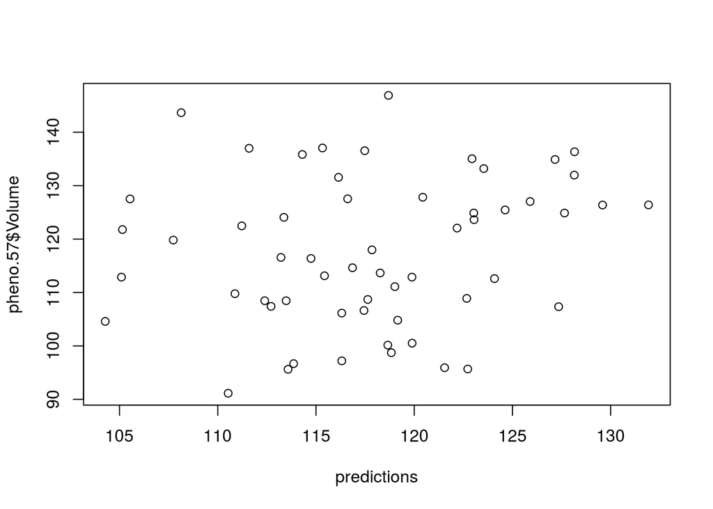

```r
cor.mat <- cor(t(scale(log2(fam.asreml.counts + 1),center=T,scale = T)))
u.fams <- colnames(cor.mat)
predictions <- unlist(sapply(1:57,function(each.fam){
  TEST.rows <- u.fams[each.fam]
  TRAIN.rows <- u.fams[-each.fam]
  okriging(idtest = TEST.rows,idtrain = TRAIN.rows,corlist = list(cor.mat),H2vec = c(.99),pheno = pheno.57,phenoname = "Volume")[,2]
}))

plot(predictions,pheno.57$Volume)
```

```r
cor(predictions,pheno.57$Volume)
```

```
## [1] 0.1724627
```

*** The BEST results are either from SCALING/NO_CENTERING or NO SCALING/CENTERING.

### 0.4.2 BCV transcripts: FAMILY-level

- BCV > 1 NO SCALE/CENTER

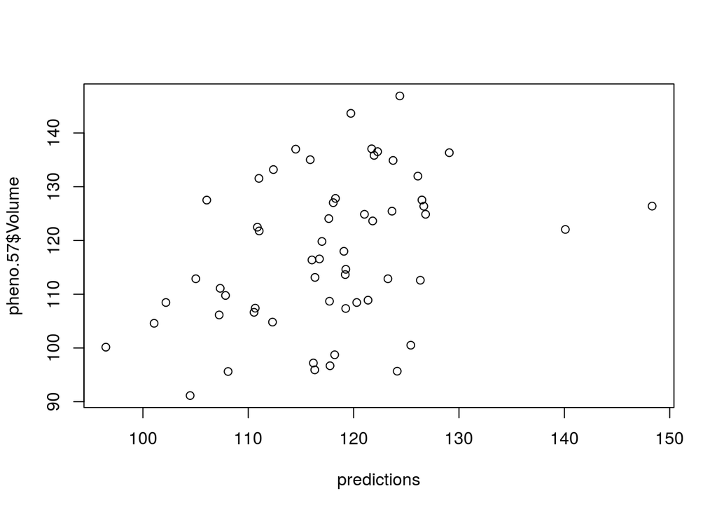

```r
mean.cts <- apply(fam.asreml.counts,2,mean)
sd.cts <- apply(fam.asreml.counts,2,sd)
bcv.cts <- sd.cts/mean.cts
cor.mat <- cor(t(log2(fam.asreml.counts[,which(bcv.cts >= 1)] + 1)))

u.fams <- colnames(cor.mat)
predictions <- unlist(sapply(1:57,function(each.fam){
  TEST.rows <- u.fams[each.fam]
  TRAIN.rows <- u.fams[-each.fam]
  okriging(idtest = TEST.rows,idtrain = TRAIN.rows,corlist = list(cor.mat),H2vec = c(.99),pheno = pheno.57,phenoname = "Volume")[,2]
}))

plot(predictions,pheno.57$Volume)
```

```r
cor(predictions,pheno.57$Volume)
```

```
## [1] 0.3832692
```

- BCV > 1 SCALED, NO CENTERING

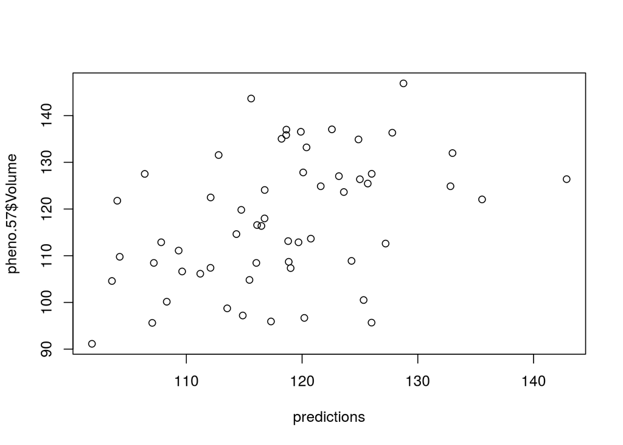

```r
cor.mat <- cor(t(scale(log2(fam.asreml.counts[,which(bcv.cts > 1)] + 1),center=F,scale = T)))

u.fams <- colnames(cor.mat)
predictions <- unlist(sapply(1:57,function(each.fam){
  TEST.rows <- u.fams[each.fam]
  TRAIN.rows <- u.fams[-each.fam]
  okriging(idtest = TEST.rows,idtrain = TRAIN.rows,corlist = list(cor.mat),H2vec = c(.99),pheno = pheno.57,phenoname = "Volume")[,2]
}))

plot(predictions,pheno.57$Volume)
```

```r
cor(predictions,pheno.57$Volume)
```

```
## [1] 0.4166412
```

- BCV > 1 SCALED & CENTERED

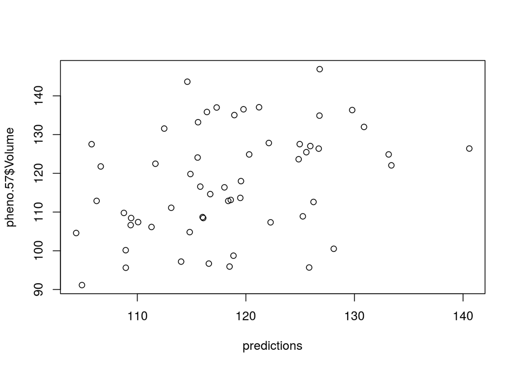

```r
cor.mat <- cor(t(scale(log2(fam.asreml.counts[,which(bcv.cts > 1)] + 1),center=T,scale = T)))

u.fams <- colnames(cor.mat)
predictions <- unlist(sapply(1:57,function(each.fam){
  TEST.rows <- u.fams[each.fam]
  TRAIN.rows <- u.fams[-each.fam]
  okriging(idtest = TEST.rows,idtrain = TRAIN.rows,corlist = list(cor.mat),H2vec = c(.99),pheno = pheno.57,phenoname = "Volume")[,2]
}))

plot(predictions,pheno.57$Volume)
```

```r
cor(predictions,pheno.57$Volume)
```

```
## [1] 0.3669412
```

*** The BEST result using BCV is done with SCALED & NO CENTERING

### 0.4.3 Linear model regression

- Conduct a linear regression from the LGEP against Volume and use sig txpts to predict EW

```
suppressPackageStartupMessages(library(parallel))
u.fams <- pheno.57$fam_id
log2.asreml.counts <- scale(log2(asreml.counts +1),center=F,scale = T)
out.var <- apply(log2.asreml.counts,2,var)
length(which(out.var < .0001))
p.vals <- mclapply(1:57,function(each.fam){
  test.fam <- which(fam.phenos$fam_id %in% u.fams[each.fam])
  train.fam <- c(1:190)[-test.fam]
  train.phenos <- fam.phenos$Volume[train.fam]
  sapply(1:ncol(asreml.counts),function(x){
    if(var(log2.asreml.counts[,x])  > .0001){
      summary(lm(train.phenos ~ log2.asreml.counts[train.fam,x]))[[4]][[8]]
    } else { 1}
    })
},mc.cores=30)
save(p.vals,file="/mnt/mnt/media/disk6/ARF/RNASEQ/LOO.pvals.RData",compress = T)
```

```r
load("/mnt/mnt/media/disk6/ARF/RNASEQ/LOO.pvals.RData")
```

##### 0.4.3.0.1 Use straight p-vals

- Try subsetting on p-value with NO fdr adjustment: 0.05, 0.01, 0.001, 0.0001

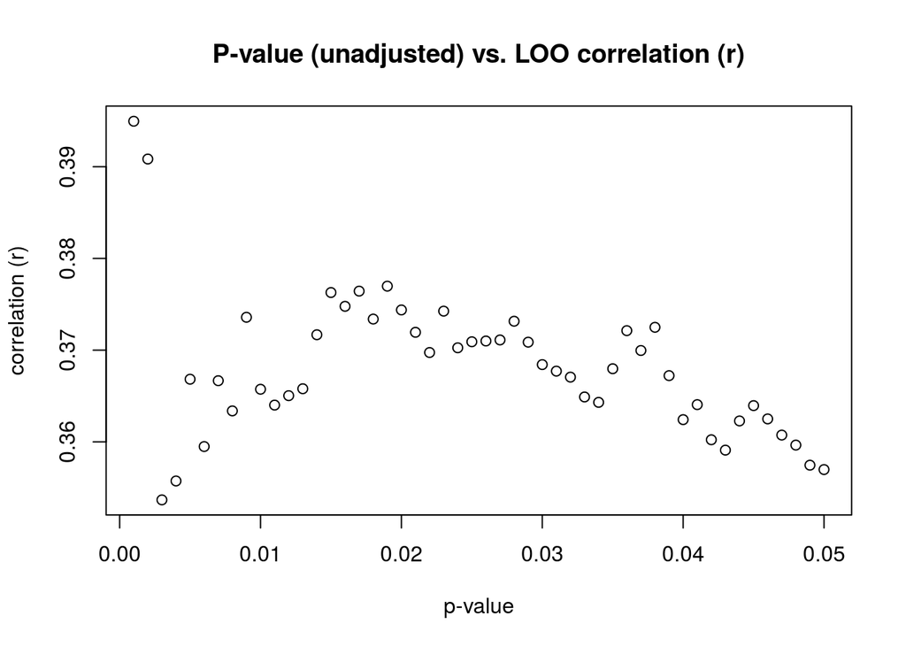

```r
p.val.subset <- seq(.001,.05,.001)
u.fams <- pheno.57$fam_id
library(parallel)
pval.cors <-  mclapply(1:length(p.val.subset),function(each.pval) {
  this.p <- p.val.subset[each.pval]
    predictions <- unlist(sapply(1:57,function(each.fam){
        cor.mat <- cor(t(scale(log2(fam.asreml.counts[,which(p.vals[[each.fam]] <= this.p)] + 1),center=F,scale = T)))
        TEST.rows <- u.fams[each.fam]
        TRAIN.rows <- u.fams[-each.fam]
        okriging(idtest = TEST.rows,idtrain = TRAIN.rows,corlist = list(cor.mat),H2vec = c(.99),pheno = pheno.57,phenoname = "Volume")[,2]
      }))

    cor(predictions,pheno.57$Volume)
},mc.cores=num.cores)

plot(p.val.subset,unlist(pval.cors),xlab="p-value", ylab="correlation (r)",main = "P-value (unadjusted) vs. LOO correlation (r)")
```

##### 0.4.3.0.2 Use pval adjust

- Generate the adjusted p-values

```r
pvals.adjust <- lapply(p.vals,function(x) p.adjust(p = x,method = "fdr"))
```

- Try subsetting on p-value with fdr adjustment: .001 to .1 by .001

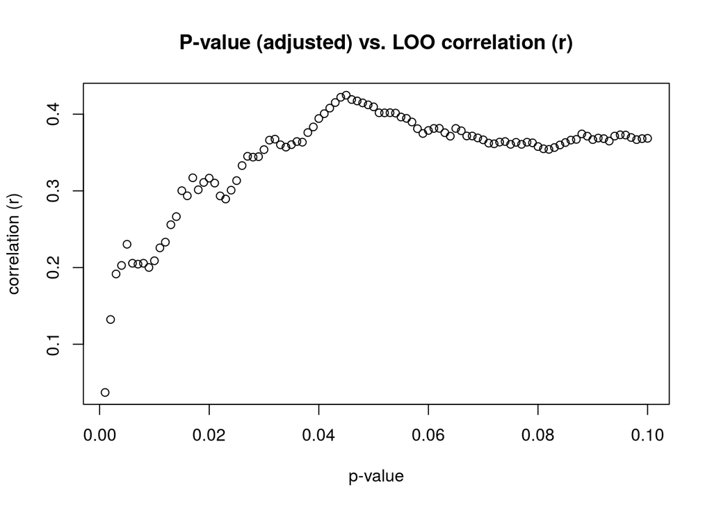

```r
p.val.subset <- seq(.001,.1,.001)
u.fams <- pheno.57$fam_id
library(parallel)
pval.adjust.cors <-  mclapply(1:length(p.val.subset),function(each.pval) {
  this.p <- p.val.subset[each.pval]
    predictions <- unlist(sapply(1:57,function(each.fam){
these.txpts <- which(pvals.adjust[[each.fam]] <= this.p)
        cor.mat <- cor(t(scale(log2(fam.asreml.counts[,these.txpts] + 1),center=F,scale = T)))
        TEST.rows <- u.fams[each.fam]
        TRAIN.rows <- u.fams[-each.fam]
        okriging(idtest = TEST.rows,idtrain = TRAIN.rows,corlist = list(cor.mat),H2vec = c(.99),pheno = pheno.57,phenoname = "Volume")[,2]
      }))

    cor(predictions,pheno.57$Volume)
},mc.cores=num.cores)

plot(p.val.subset,unlist(pval.adjust.cors),xlab="p-value", ylab="correlation (r)",main = "P-value (adjusted) vs. LOO correlation (r)")
```

- Try combining the fdr adjusted p-values and the BCV > 1

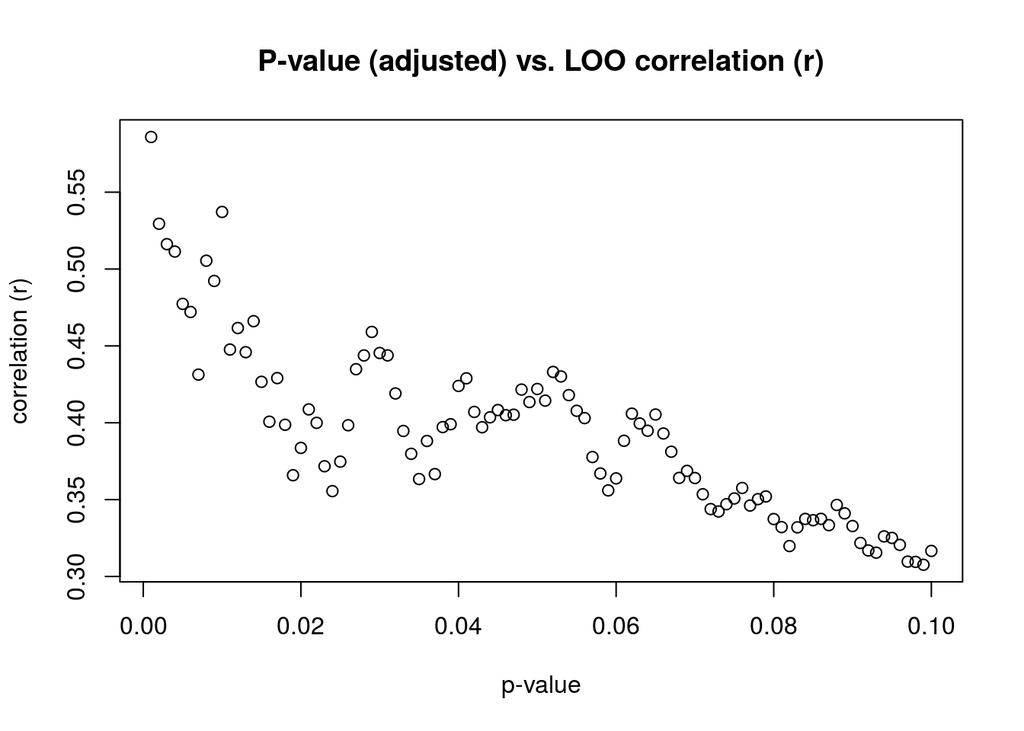

```r
p.val.subset <- seq(.001,.1,.001)
u.fams <- pheno.57$fam_id
pval.adjust.cors <-  mclapply(1:length(p.val.subset),function(each.pval) {
  this.p <- p.val.subset[each.pval]
    predictions <- unlist(sapply(1:57,function(each.fam){
these.txpts <- which(pvals.adjust[[each.fam]] <= this.p)
mean.cts <- apply(fam.asreml.counts[,these.txpts],2,mean)
sd.cts <- apply(fam.asreml.counts[,these.txpts],2,sd)
bcv.cts <- sd.cts/mean.cts

        cor.mat <- cor(t(scale(log2(fam.asreml.counts[,these.txpts[which(bcv.cts >= 1)]] + 1),center=F,scale = T)))
        TEST.rows <- u.fams[each.fam]
        TRAIN.rows <- u.fams[-each.fam]
        okriging(idtest = TEST.rows,idtrain = TRAIN.rows,corlist = list(cor.mat),H2vec = c(.99),pheno = pheno.57,phenoname = "Volume")[,2]
      }))

    cor(predictions,pheno.57$Volume)
},mc.cores=num.cores)

plot(p.val.subset,unlist(pval.adjust.cors),xlab="p-value", ylab="correlation (r)",main = "P-value (adjusted) vs. LOO correlation (r)")
```

### 0.4.4 GLMNET

- Try GLMNET with adjusted p-vals and Alpha set to 1

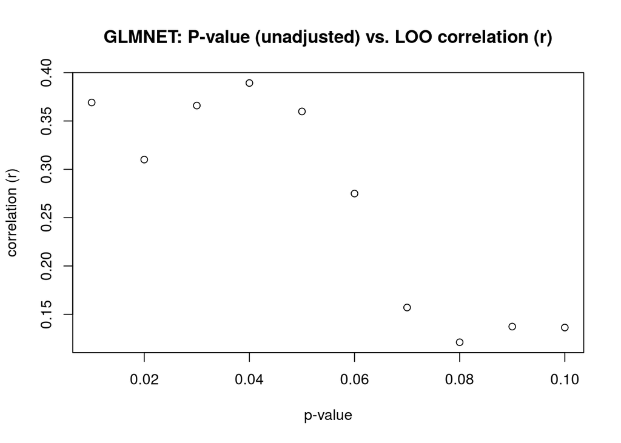

```r
suppressPackageStartupMessages(library(glmnet))
p.val.subset <- seq(.01,.1,.01)
gl.cors <-  mclapply(1:length(p.val.subset),function(each.pval) {
  this.p <- p.val.subset[each.pval]
    predictions <- unlist(sapply(1:57,function(each.fam){
      these.txpts <- which(pvals.adjust[[each.fam]] <= this.p)
      cts <- log2(fam.asreml.counts[,these.txpts] + 1)
        gl.mod <- glmnet(x = cts[-each.fam,],y = pheno.57$Volume[-each.fam],alpha = 1,standardize = F)
              prediction <- predict.glmnet(gl.mod,newx = cts)
        prediction[each.fam,ncol(prediction)]
      }))

    cor(predictions,pheno.57$Volume)
},mc.cores=num.cores)

plot(p.val.subset,unlist(gl.cors),xlab="p-value", ylab="correlation (r)",main = "GLMNET: P-value (unadjusted) vs. LOO correlation (r)")
```

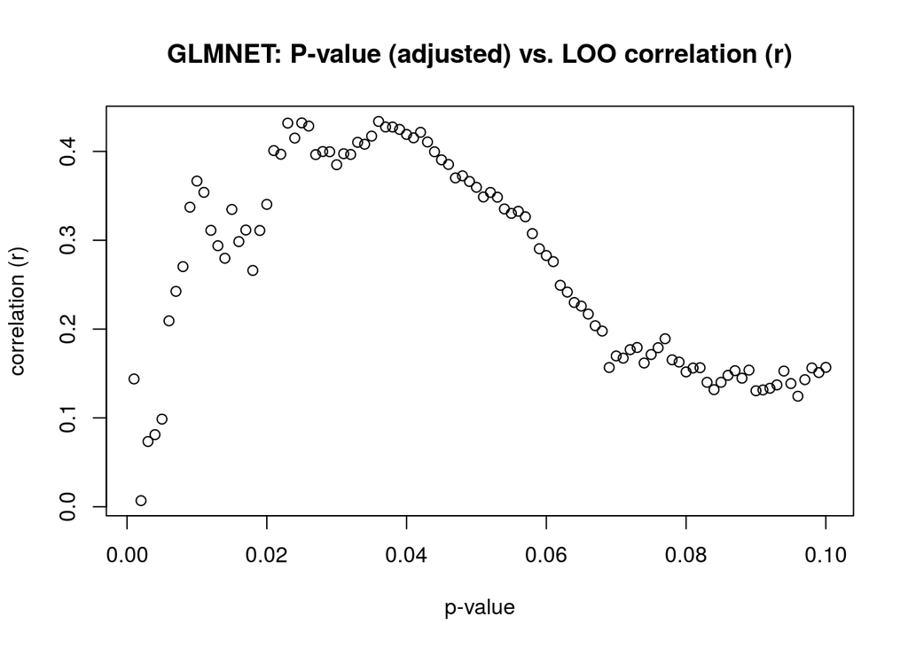

```r
p.val.subset <- seq(.001,.1,.001)
# ALPHA = .5 Try on adjusted pvals
gl.cors <-  mclapply(1:length(p.val.subset),function(each.pval) {
  this.p <- p.val.subset[each.pval]
    predictions <- unlist(sapply(1:57,function(each.fam){
      these.txpts <- which(pvals.adjust[[each.fam]] <= this.p)
      cts <- log2(fam.asreml.counts[,these.txpts] + 1)
        gl.mod <- glmnet(x = cts[-each.fam,],y = pheno.57$Volume[-each.fam],alpha = .5,standardize = F)
              prediction <- predict.glmnet(gl.mod,newx = cts)
        prediction[each.fam,ncol(prediction)]
      }))

    cor(predictions,pheno.57$Volume)
},mc.cores=num.cores)


plot(p.val.subset,unlist(gl.cors),xlab="p-value", ylab="correlation (r)",main = "GLMNET: P-value (adjusted) vs. LOO correlation (r)")
```

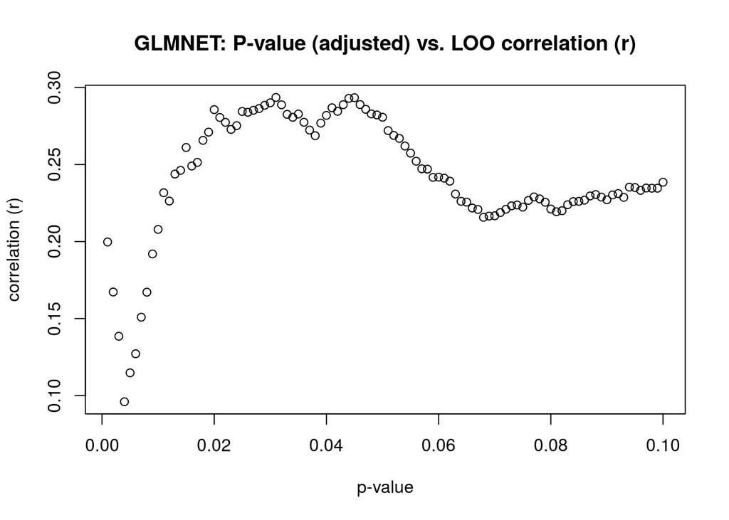

```r
# ALPHA = 0
gl.cors <-  mclapply(1:length(p.val.subset),function(each.pval) {
  this.p <- p.val.subset[each.pval]
    predictions <- unlist(sapply(1:57,function(each.fam){
          gl.mod <- glmnet(x = log2(fam.asreml.counts[-each.fam,which(pvals.adjust[[each.fam]] <= this.p)] + 1),
                  y = pheno.57$Volume[-each.fam],alpha = 0,standardize = F)
              prediction <- predict.glmnet(gl.mod,newx = log2(fam.asreml.counts[,which(pvals.adjust[[each.fam]] <= this.p)] + 1))
        prediction[each.fam,ncol(prediction)]
      }))

    cor(predictions,pheno.57$Volume)
},mc.cores=num.cores)

plot(p.val.subset,unlist(gl.cors),xlab="p-value", ylab="correlation (r)",main = "GLMNET: P-value (adjusted) vs. LOO correlation (r)")
```

- Try GLMNET on all data

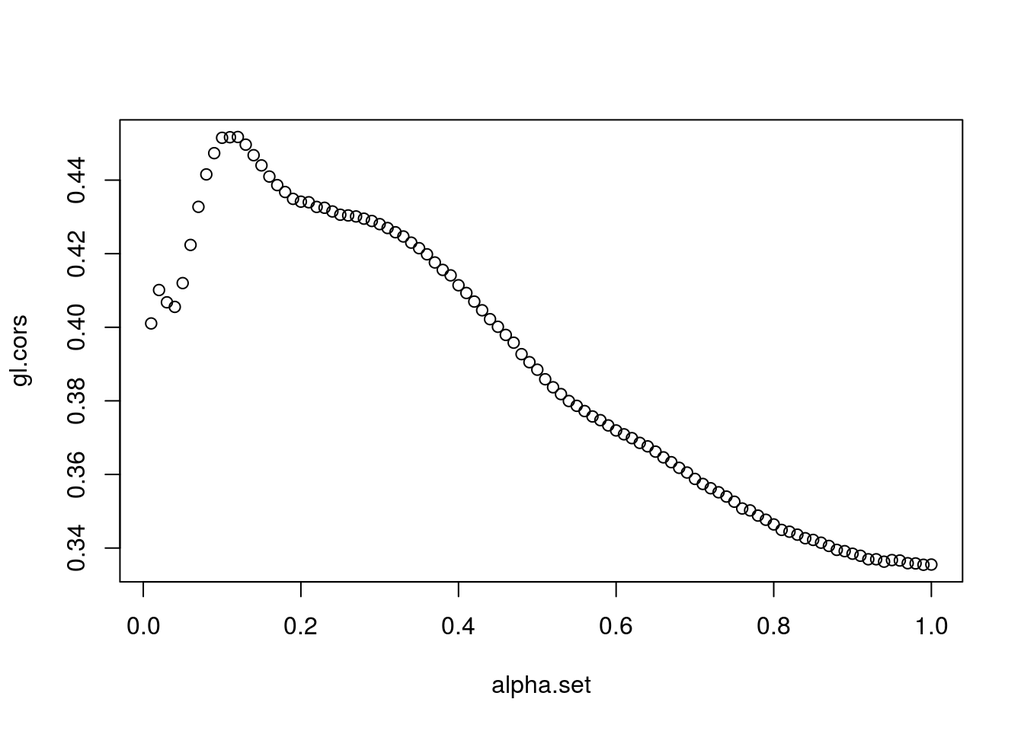

```r
alpha.set <- seq(.01,1,.01)

gl.cors <-  mclapply(1:length(alpha.set),function(each.alpha) {
  this.a <- alpha.set[each.alpha]

    predictions <- unlist(sapply(1:57,function(each.fam){
          gl.mod <- glmnet(x = log2(fam.asreml.counts[-each.fam,] + 1),
                  y = pheno.57$Volume[-each.fam],alpha = this.a,standardize = F)
              prediction <- predict.glmnet(gl.mod,newx = log2(fam.asreml.counts + 1))
        prediction[each.fam,ncol(prediction)]
      }))

    cor(predictions,pheno.57$Volume)
},mc.cores=num.cores)

plot(alpha.set,gl.cors)
```